# PAC report

2023-12-07

For this Kaggle competition, we got a dataset of 40000 used cars and need to predict the used cars price by using some of these 46 variables.

There are three parts in my report: (1) Exploring the data (EDA) (2) Preparing the data (Data cleaning) (3) Analysis technique (Feature selection, Model Selection)

#Exploring the data/ Preparing the data

My first step was to load data and libraries, and then I started to explore data structure using the str function. In my first attempt (d), I only selected numerical variables and tried to calculate a new variable, “total_volume,” by combining height, weight, and length. However, the result didn’t turn out well.

In my other attempt (cdata), I started to add some numerical variables. I extracted the first three characters of the “torque” variable and created a new variable, “torque_n,” which means number only. Also, I converted some categorical variables to numerical, such as “is_new,” “make_name,” and “listing_color.” I think these elements are essential when predicting a used car’s price.

When exploring the data, I noticed several NAs in the dataset. My first instinct was to remove all NAs, but since there were too many, it influenced the accuracy of our future prediction. So, after a couple of tries, I decided to replace missing values with the median for selected variables.

Before selecting which variables to use, I visualized the data using ggplot2, trying to find the relationship between variables. I also used corrplot and cor function to do correlation analysis.

```r
getwd()
```

```
## [1] "/Users/tinalin/Desktop"
```

```r
setwd("/Users/tinalin/Downloads")
data = read.csv('analysisData.csv')

library(xgboost)
library(vtreat)
```

```r
library(ggplot2)
library(dplyr)
library(corrplot)
library(broom)
library(caret)
library(car)
library(leaps)
library(stats)
library(gbm)
str(data)
```

```
## 'data.frame':    40000 obs. of  46 variables:
##  $ id                      : int  1249155 3545171 2712521 3187710 7698388 3714549 3639774 7706229 8374155 8368805 ...
##  $ make_name               : chr  "Chevrolet" "Nissan" "Ford" "Volvo" ...
##  $ model_name              : chr  "Equinox" "Altima" "Fusion Hybrid" "XC90" ...
##  $ trim_name               : chr  "1.5T LT AWD" "2.5 S FWD" "SE FWD" "Recharge Inscription 7-Passenger eAWD" ...
##  $ body_type               : chr  "SUV / Crossover" "Sedan" "Sedan" "SUV / Crossover" ...
##  $ fuel_tank_volume_gallons: num  15.6 16.2 14 18.5 13.2 19.5 17.5 21 17.5 24.6 ...
##  $ fuel_type               : chr  "Gasoline" "Gasoline" "Hybrid" "Gasoline" ...
##  $ highway_fuel_economy    : int  30 39 41 28 37 27 28 25 27 NA ...
##  $ city_fuel_economy       : int  25 28 43 26 29 20 19 22 19 NA ...
##  $ power                   : chr  "170 hp @ 5,600 RPM" "188 hp @ 6,000 RPM" "" "400 hp @ 6,000 RPM" ...
##  $ torque                  : chr  "203 lb-ft @ 2,000 RPM" "180 lb-ft @ 3,600 RPM" "" "472 lb-ft @ 2,200 RPM" ...
##  $ transmission            : chr  "A" "CVT" "CVT" "A" ...
##  $ transmission_display    : chr  "Automatic" "Continuously Variable Transmission" "Continuously Variable Transmission" "Automatic" ...
##  $ wheel_system            : chr  "4WD" "FWD" "FWD" "AWD" ...
```

[output cut: 32 more lines]

```r
#first attempt - only select numerical variables
d<- data %>%
  select_if(~is.numeric(.))%>%
  mutate(total_volume=length_inches*width_inches*height_inches)

cdata<- data %>%
  mutate(total_volume=length_inches*width_inches*height_inches)%>%
  mutate(torque_n=substr(torque, 1, 3))

#make categorical to numerical
cdata$is_new <- as.integer(as.logical(cdata$is_new))
cdata$make_name <- as.numeric(as.factor(cdata$make_name))
cdata$listing_color <- as.numeric(as.factor(cdata$listing_color))
cdata$torque_n <- as.integer(cdata$torque_n)

#replace NAs with median
cdata$owner_count[is.na(cdata$owner_count)] <- median(cdata$owner_count, na.rm = TRUE)
cdata$mileage[is.na(cdata$mileage)] <- median(cdata$mileage, na.rm = TRUE)
cdata$engine_displacement[is.na(cdata$engine_displacement)] <- median(cdata$engine_displacement, na.rm = TRUE)
cdata$highway_fuel_economy[is.na(cdata$highway_fuel_economy)] <- median(cdata$highway_fuel_economy, na.rm = TRUE)
cdata$horsepower[is.na(cdata$horsepower)] <- median(cdata$horsepower, na.rm = TRUE)
cdata$fuel_tank_volume_gallons[is.na(cdata$fuel_tank_volume_gallons)] <- median(cdata$fuel_tank_volume_gallons, na.rm = TRUE)
cdata$seller_rating[is.na(cdata$seller_rating)] <- median(cdata$seller_rating, na.rm = TRUE)
cdata$city_fuel_economy[is.na(cdata$city_fuel_economy)] <- median(cdata$city_fuel_economy, na.rm = TRUE)
cdata$torque_n[is.na(cdata$torque_n)] <- median(cdata$torque_n, na.rm = TRUE)

car_data <- d[complete.cases(d), ]
cor(car_data)
```

```
##                                     id fuel_tank_volume_gallons
## id                        1.0000000000             -0.003911003
## fuel_tank_volume_gallons -0.0039110033              1.000000000
## highway_fuel_economy      0.0014328192             -0.753130462
## city_fuel_economy         0.0035656516             -0.714215197
## wheelbase_inches          0.0003573366              0.778323736
## back_legroom_inches       0.0082229022              0.243850796
## front_legroom_inches     -0.0067465839              0.059310251
## length_inches            -0.0004610072              0.789134318
## width_inches              0.0097970933              0.600067838
## height_inches            -0.0092012374              0.688219653
## engine_displacement      -0.0027034935              0.792141008
## horsepower                0.0029789536              0.748180408
## daysonmarket              0.0055128461              0.007932135
## maximum_seating          -0.0038698017              0.496925162
## year                      0.0020429880             -0.114991589
## mileage                  -0.0079123678              0.161134110
## owner_count               0.0031702201              0.077005762
## seller_rating             0.0008719478              0.044172311
## price                    -0.0039712132              0.385594853
## total_volume             -0.0009458379              0.818339236
##                          highway_fuel_economy city_fuel_economy
## id                                0.001432819       0.003565652
## fuel_tank_volume_gallons         -0.753130462      -0.714215197
## highway_fuel_economy              1.000000000       0.913535654
## city_fuel_economy                 0.913535654       1.000000000
## wheelbase_inches                 -0.542024536      -0.500704810
## back_legroom_inches              -0.135580148      -0.102486345
## front_legroom_inches              0.100525450       0.064641099
## length_inches                    -0.517580946      -0.507943227
## width_inches                     -0.522779169      -0.492562222
## height_inches                    -0.712429215      -0.549446517
## engine_displacement              -0.740665989      -0.707912693
## horsepower                       -0.711117155      -0.696669393
## daysonmarket                     -0.029100874      -0.032926556
## maximum_seating                  -0.445383138      -0.386500660
## year                              0.239692719       0.231292468
## mileage                          -0.207233622      -0.196560163
## owner_count                      -0.146132956      -0.162250247
## seller_rating                    -0.046362849      -0.049285684
```

[output cut: 92 more lines]

```
## back_legroom_inches      -0.125268744 -0.0448726070  0.155921280  0.3700348321
## front_legroom_inches     -0.065211155 -0.0218057902  0.083564170  0.0174391046
## length_inches            -0.021444655  0.0207509407  0.366139879  0.8289852874
## width_inches             -0.078109490  0.0706986024  0.402257584  0.8150259278
## height_inches            -0.045854990  0.0081284831  0.292336812  0.8428324971
## engine_displacement       0.118662917  0.0308525251  0.378402018  0.6743553576
## horsepower                0.005813252  0.0655144478  0.611264688  0.6785103407
## daysonmarket              0.183903552 -0.0123190721 -0.107726222 -0.0362528498
## maximum_seating          -0.044226714 -0.0133085160  0.141422301  0.5883718646
## year                     -0.603216168 -0.0694790723  0.482204182  0.0671545706
## mileage                   0.551337482  0.0430286081 -0.513396983  0.0271897584
## owner_count               1.000000000  0.0015107787 -0.327926193 -0.0551466533
## seller_rating             0.001510779  1.0000000000  0.063577252  0.0381429875
## price                    -0.327926193  0.0635772524  1.000000000  0.4064559375
## total_volume             -0.055146653  0.0381429875  0.406455937  1.0000000000
```

```r
#corrplot(d_,method = "color",order="alphabet")
#corrplot(d_cor,order="AOE")
#corrplot(d_cor,method = "number",number.cex = 0.5)
#corrplot(carp,method="number")

carr<- cdata%>%
  select_if(~is.numeric(.))%>%
  subset(select=-c(length_inches,width_inches,height_inches))
```

#Analysis technique

The first step was doing data splitting. I split the data into training and test sets based on the price variable, with 80% of the data assigned to the training set (train) and 20% to the test set (test). Then I performed subset selection using the regsubsets function, considering up to 21 variables in the linear regression model, and created a data frame (subsets_measures) with measures such as Cp, BIC, and adjusted R-squared for each model in the subset selection process. Besides, I also did backward stepwise regression, eliminating variables from the model based on minimizing the AIC until the optimal model is reached.

For the model selection process, I’ve tried various models, but the most successful one for me is the XGBoost model. The code defined features and the target variable (price), converted training and test data into XGBoost DMatrix format and then built an XGBoost model with 2000 rounds and verbose output for effective car price prediction. I also experimented with rounds number, trying different combinations for a better outcome.

```r
set.seed(1031)
split = createDataPartition(y=carr$price,p = 0.8,list = F,groups = 100)
train = carr[split,]
test = carr[-split,]

subsets = regsubsets(price~.,data=train, nvmax=21)
summary(subsets)
```

```
## Subset selection object
## Call: regsubsets.formula(price ~ ., data = train, nvmax = 21)
## 20 Variables  (and intercept)
##                          Forced in Forced out
## id                           FALSE      FALSE
## make_name                    FALSE      FALSE
## fuel_tank_volume_gallons     FALSE      FALSE
## highway_fuel_economy         FALSE      FALSE
## city_fuel_economy            FALSE      FALSE
## wheelbase_inches             FALSE      FALSE
## back_legroom_inches          FALSE      FALSE
## front_legroom_inches         FALSE      FALSE
## engine_displacement          FALSE      FALSE
## horsepower                   FALSE      FALSE
## daysonmarket                 FALSE      FALSE
```

[output cut: 116 more lines]

```r
subsets_measures = data.frame(model=1:length(summary(subsets)$cp),
                              cp=summary(subsets)$cp,
                              bic=summary(subsets)$bic,
                              adjr2=summary(subsets)$adjr2)
subsets_measures
```

```
##    model          cp       bic     adjr2
## 1      1 34705.09013 -16732.47 0.4071346
## 2      2  7235.62831 -33715.90 0.6511399
## 3      3  5222.81286 -35393.12 0.6690267
## 4      4  4146.56536 -36323.76 0.6785949
## 5      5  2968.73104 -37375.75 0.6890661
## 6      6  2460.66936 -37835.78 0.6935877
## 7      7  2030.51454 -38229.44 0.6974175
## 8      8  1525.77027 -38699.42 0.7019102
## 9      9  1142.96017 -39058.69 0.7053198
## 10    10   775.18973 -39407.57 0.7085961
## 11    11   625.67475 -39545.57 0.7099332
## 12    12   263.44671 -39894.72 0.7131605
## 13    13   183.53162 -39965.76 0.7138795
## 14    14   123.57864 -40017.10 0.7144211
## 15    15    81.18565 -40051.02 0.7148066
## 16    16    45.51228 -40078.28 0.7151325
## 17    17    28.55885 -40086.86 0.7152921
## 18    18    23.64293 -40083.40 0.7153447
## 19    19    21.40138 -40077.27 0.7153735
## 20    20    21.00000 -40069.30 0.7153859
```

```r
#based on CP - 21 variables
#based on BIC - 17 variables
#based on adjr2 - 20 variables

start_mod = lm(price~.,data=train)
empty_mod = lm(price~1,data=train)
full_mod = lm(price~.,data=train)
backwardStepwise = step(start_mod,
                        scope=list(upper=full_mod,lower=empty_mod),
                        direction='backward')
```

```
## Start:  AIC=584945.1
## price ~ id + make_name + fuel_tank_volume_gallons + highway_fuel_economy +
##     city_fuel_economy + wheelbase_inches + back_legroom_inches +
##     front_legroom_inches + engine_displacement + horsepower +
##     daysonmarket + maximum_seating + year + is_new + listing_color +
##     mileage + owner_count + seller_rating + total_volume + torque_n
##
##                            Df  Sum of Sq        RSS    AIC
## <none>                                   2.7101e+12 584945
## - id                        1 2.0323e+08 2.7103e+12 584945
## - listing_color             1 3.6139e+08 2.7104e+12 584947
## - maximum_seating           1 5.6593e+08 2.7106e+12 584950
## - owner_count               1 1.6765e+09 2.7117e+12 584963
## - back_legroom_inches       1 3.1919e+09 2.7132e+12 584981
## - daysonmarket              1 4.1045e+09 2.7142e+12 584992
## - front_legroom_inches      1 4.9853e+09 2.7150e+12 585002
## - total_volume              1 6.9091e+09 2.7170e+12 585025
## - wheelbase_inches          1 1.7419e+10 2.7275e+12 585148
## - year                      1 3.1649e+10 2.7417e+12 585315
## - seller_rating             1 3.1805e+10 2.7419e+12 585317
## - make_name                 1 3.3409e+10 2.7435e+12 585336
## - highway_fuel_economy      1 3.3588e+10 2.7436e+12 585338
## - city_fuel_economy         1 4.7229e+10 2.7573e+12 585497
## - torque_n                  1 5.5783e+10 2.7658e+12 585596
## - fuel_tank_volume_gallons  1 7.0395e+10 2.7804e+12 585765
## - engine_displacement       1 8.4632e+10 2.7947e+12 585928
## - is_new                    1 1.3270e+11 2.8427e+12 586475
## - mileage                   1 1.3666e+11 2.8467e+12 586520
## - horsepower                1 7.3617e+11 3.4462e+12 592644
```

```r
#XGBoost

features = c('year','horsepower','mileage','owner_count','listing_color','maximum_seating','make_name','is_new','wheelbase_inches','back_legroom_inches','front_legroom_inches','engine_displacement','total_volume','daysonmarket','seller_rating','torque_n','fuel_tank_volume_gallons','highway_fuel_economy')
target = 'price'

xgtrain = xgb.DMatrix(data = as.matrix(train[, features]),
                      label = train[, target])
xgtest = xgb.DMatrix(data = as.matrix(test[, features]),
                     label = test[, target])

model = xgboost(data=xgtrain, nrounds=2000, verbose = 1)
```

#Other models I’ve used

I also used Boosting with XGBoost, multiple regression and tuned random forest. (Tuned random forest did not run at all, so I already deleted the code) Besides, I spent a lot of time trying our different variable combinations and avoiding overfitting.

```r
##Boosting with XGBoost
trt = designTreatmentsZ(dframe = train,
                        varlist = names(train)[c(2:18,20,21)])
```

```
## [1] "vtreat 1.6.4 inspecting inputs Sat Dec  9 12:40:14 2023"
## [1] "designing treatments Sat Dec  9 12:40:14 2023"
## [1] " have initial level statistics Sat Dec  9 12:40:14 2023"
## [1] " scoring treatments Sat Dec  9 12:40:14 2023"
## [1] "have treatment plan Sat Dec  9 12:40:14 2023"
```

```r
newvars = trt$scoreFrame[trt$scoreFrame$code%in% c('clean','lev'),'varName']

#prepare data for XGBoost
train_input = prepare(treatmentplan = trt,
                      dframe = train,
                      varRestriction = newvars)
test_input = prepare(treatmentplan = trt,
                     dframe = test,
                     varRestriction = newvars)

head(train_input)
```

```
##   make_name fuel_tank_volume_gallons highway_fuel_economy city_fuel_economy
## 1         8                     15.6                   30                25
## 2        34                     16.2                   39                28
## 3        13                     14.0                   41                43
## 4        46                     18.5                   28                26
## 5        34                     13.2                   37                29
## 6        26                     17.5                   28                19
##   wheelbase_inches back_legroom_inches front_legroom_inches engine_displacement
## 1            107.3                39.9                 40.9                1500
## 2            111.2                35.2                 43.8                2500
## 3            112.2                38.3                 44.3                2000
## 4            117.5                37.0                 40.9                2000
## 5            106.3                37.4                 42.5                1800
## 6            112.2                37.0                 44.3                3700
##   horsepower daysonmarket maximum_seating year is_new listing_color mileage
## 1        170           15               5 2023      1            13       4
## 2        188           16               5 2023      1             5       5
## 3        188           50               5 2023      1             2      30
## 4        400           13               7 2024      1            13       0
## 5        130            5               5 2020      0            12   37260
## 6        300           21               5 2016      0            13   49254
##   owner_count seller_rating total_volume torque_n
## 1           1      4.333333     869366.1      203
## 2           1      3.203704     797338.6      180
## 3           1      4.296296     928887.4      258
## 4           1      4.476190    1149051.2      472
## 5           1      4.470588     743290.3      258
## 6           3      4.272727     941008.4      277
```

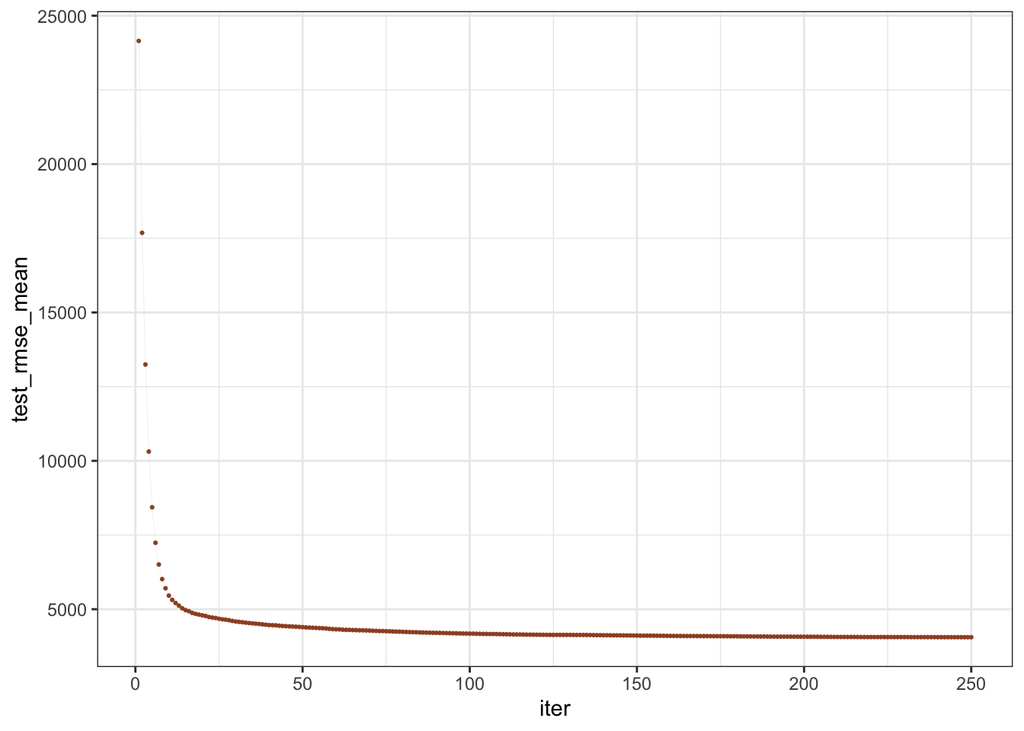

```r
#Tune XGBoost Parameters
set.seed(1031)
tune_nrounds = xgb.cv(data=as.matrix(train_input),
                      label = train$price,
                      nrounds=250,
                      nfold = 5,
                      verbose = 0)

#Visualize Tuning Results
ggplot(data=tune_nrounds$evaluation_log, aes(x=iter, y=test_rmse_mean))+
  geom_point(size=0.4, color='sienna')+
  geom_line(size=0.1, alpha=0.1)+
  theme_bw()
```

```r
#Identify Optimal Number of Rounds
which.min(tune_nrounds$evaluation_log$test_rmse_mean)
```

```
## [1] 249
```

```r
#Train XGBoost Model
xgboost2= xgboost(data=as.matrix(train_input),
                  label = train$price,
                  nrounds=249,
                  verbose = 0)

#Evaluate XGBoost Model on Test Data
pred = predict(xgboost2,
               newdata=as.matrix(test_input))

rmse_xgboost = sqrt(mean((pred - test$price)^2))
rmse_xgboost ## 3420.524
```

```
## [1] 3420.524
```

```r
## Multiple Regression
model1=lm(price~fuel_tank_volume_gallons + highway_fuel_economy + city_fuel_economy +
            front_legroom_inches + total_volume +
            engine_displacement + horsepower + maximum_seating + year +
            mileage + owner_count + seller_rating,data=train)

pred=predict(model1)
sse = sum((pred - train$price)^2)
sst = sum((mean(train$price)-train$price)^2)
model1_r2 = 1 - sse/sst; model1_r2
```

```
## [1] 0.6886577
```

```r
rmse = sqrt(mean((pred-train$price)^2)); rmse #rsme=7504.565 (model1 train)
```

```
## [1] 9621.48
```

```r
predt = predict(model1, newdata=test)
sse_test = sum((predt - test$price)^2)
sst_test = sum((mean(train$price)-test$price)^2)
model1_r2_test = 1 - sse_test/sst_test;
rmse_test = sqrt(mean((predt-test$price)^2));

rmse_test #rsme_test=7817.461 (model1 test)
```

```
## [1] 8766.599
```

#Scoring Data

I applied the same data cleaning process on Scoring Data, making sure the variables were aligned, and then I started to make predictions using the pre-trained model. Last, I created submission files with predicted prices and corresponding IDs from the scoring dataset, wrote them to a CSV file and submitted.

```r
getwd()
```

```
## [1] "/Users/tinalin/Desktop"
```

```r
setwd("/Users/tinalin/Desktop")
scoringData = read.csv("scoringData.csv")

scoringData1<- scoringData %>%
  mutate(total_volume=length_inches*width_inches*height_inches)%>%
  mutate(torque_n=substr(torque, 1, 3))

#make categorical to numerical
scoringData1$is_new <- as.integer(as.logical(scoringData1$is_new))
scoringData1$make_name <- as.numeric(as.factor(scoringData1$make_name))
scoringData1$listing_color <- as.numeric(as.factor(scoringData1$listing_color))
scoringData1$torque_n <- as.integer(scoringData1$torque_n)

#replace NAs with median
scoringData1$owner_count[is.na(scoringData$owner_count)] <- median(scoringData1$owner_count, na.rm = TRUE)
scoringData1$city_fuel_economy[is.na(scoringData$city_fuel_economy)] <- median(scoringData1$city_fuel_economy, na.rm = TRUE)
scoringData1$mileage[is.na(scoringData$mileage)] <- median(scoringData1$mileage, na.rm = TRUE)
scoringData1$engine_displacement[is.na(scoringData$engine_displacement)] <- median(scoringData1$engine_displacement, na.rm = TRUE)
scoringData1$highway_fuel_economy[is.na(scoringData$highway_fuel_economy)] <- median(scoringData1$highway_fuel_economy, na.rm = TRUE)
scoringData1$horsepower[is.na(scoringData$horsepower)] <- median(scoringData1$horsepower, na.rm = TRUE)
scoringData1$seller_rating[is.na(scoringData$seller_rating)] <- median(scoringData1$seller_rating, na.rm = TRUE)
scoringData1$fuel_tank_volume_gallons[is.na(scoringData$fuel_tank_volume_gallons)] <- median(scoringData1$fuel_tank_volume_gallons, na.rm = TRUE)
scoringData1$torque_n[is.na(scoringData1$torque_n)] <- median(scoringData1$torque_n, na.rm = TRUE)

scoringData2<- scoringData1%>%
  select_if(~is.numeric(.))%>%
  subset(select=-c(length_inches,width_inches,height_inches))

pred = predict(model, newdata = as.matrix(scoringData2[, features]))
submissionFile = data.frame(id = scoringData$id, price = pred)
write.csv(submissionFile, 'sample_submission.csv',row.names = F)
```